# README

## Effects of Environmental Drivers Across Ecological Scales

### Investigators (alphabetical listing)

- Allison Case - Endocrine lab manager, SEZARC
- Jeremy A. Collings - PhD candidate, University of Oregon
- Joey Krieger Lodge - PhD student, University of Colorado, Boulder
- Evald Maceno - PhD candidate, Univeristy of Puerto Rico, Río Piedras
- Sierra B. Perez - PhD candidate, Indiana University
- Bethany L. Williams - Postdoctoral fellow, University of Missouri, St. Louis

## Project Description

### Motivation

Anthropogenic impacts are rapidly altering historic environmental conditions, with consequences across ecological scales. In fish, body size is an important trait that relates to fitness, and therefore, changes in body size are likely to cause notable effects at both the population and community level. There is evidence that changes in temperature and dissolved oxygen (DO), both of which are shifting under climate change, affect body size in fish. However, most studies looking at body size changes to date rely on museum studies, short-term experimental data, space for time substitutions, or size data from harvested fish (Arismendi et al. 2024, Coghlan et al. 2024). Additionally, an existing long-term study of reef fish indicates that the effects of temperature are not consistent across species (Audzijonyte et al. 2020), leaving an open question for how entire communities of fish will respond to increasing temperatures.

### Questions

Here, we use a synthetic approach leveraging long-term (5+ year) datasets from LTER and NEON sites that directly capture long-term changes in environmental drivers (temperature and DO), and fish body sizes, population abundances, and community properties to address the following key questions:

1. Do long-term changes in temperature and/or DO correlate with changes in body size, population abundance, total community abundance, and/or community diversity?
2. Are changes across different levels of ecological complexity (individual, population, community) correlated?
3. Can intra- or interspecific variation in responses at one ecological level explain responses at higher levels of organization?
4. Are patterns consistent across marine and freshwater ecosystems?

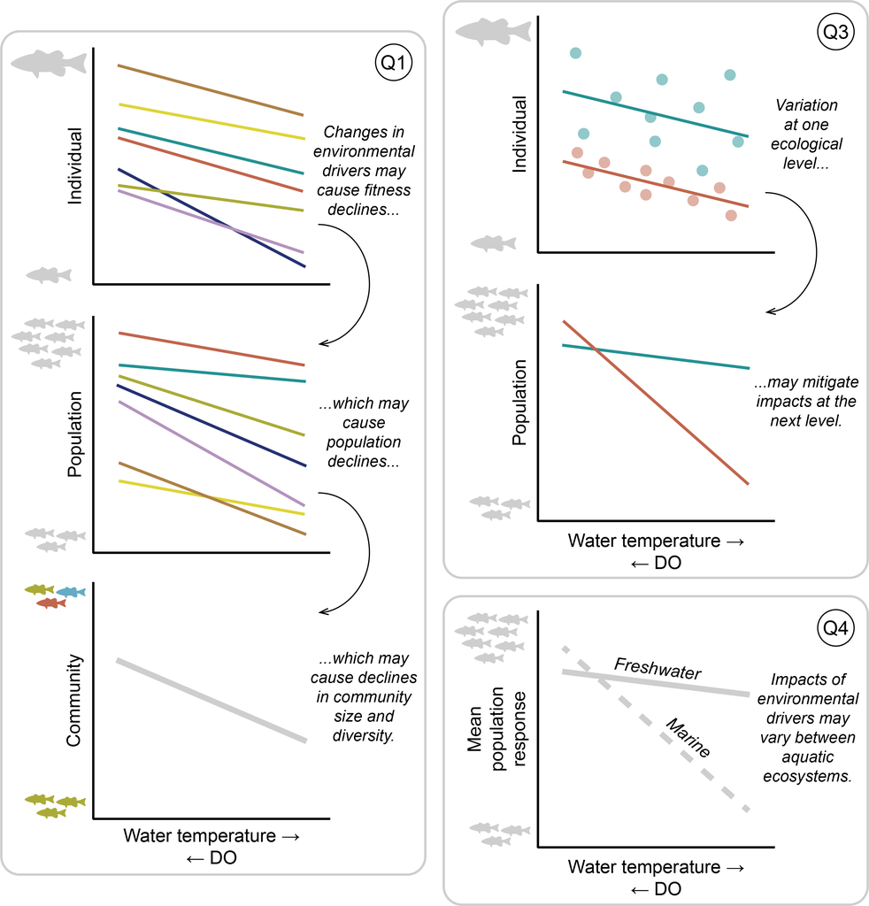

### Approach

To estimate the effects of temperature and DO on individuals, populations, and communities, we plan to fit a series of hierarchical linear models, one model per each of the following scaled response variables: body size (individual-level), standardized catch per species (population-level), species diversity (community-level), and standardized catch across species (community-level). Assuming a sufficiently weak correlation between temperature and DO, we will include both variables as fixed effects in each of our four models. Additionally, each model will include spatial random intercepts to account for other sources of meaningful environmental variation among sites. Our individual and population level models will also include random slopes for species to estimate interspecific variation in temperature and DO effects. Finally, each of these models will be fit with data from either freshwater or marine sites, resulting in eight models in total.  
We will use estimates of temperature and DO effects to evaluate Question 1. Comparisons between slope parameters across our individual, population, and community-level models will be used to evaluate Question 2. For Question 3, we will compare the variation in environmental driver effects at one ecological level with the magnitude of those effects at the next higher level. Finally, each of these heuristics will be performed for freshwater and marine systems, and a comparison of conclusions made across these two ecosystems will be used to evaluate Question 4.

## Script Explanations

Intermediate_scripts folder: There is one R script per site that is used to download, combine, and harmonize the relevant fish and environmental dataset(s) from EDI. The intermediate_harmonize script is then used to combine all the datasets from each site.

## Supplementary Resources

LTER Scientific Computing Team [website](https://lter.github.io/scicomp/) & NCEAS’ [Resources for Working Groups](https://www.nceas.ucsb.edu/working-group-resources)